# ROSMAP snRNA-seq: QC to Clustering

Minghui Wang

November 23, 2021

## Example pipeline to perform snRNA-seq data analysis using the ROSMAP data

First, dowload the snRNA-seq count matrix and associated meta tables into a folder, say, “Data”. In this tutorial, we will download the filtered data provided by Mathys et al from the Synapse at https://www.synapse.org/#!Synapse:syn18681734. After downloading, the Data folder should have the following files: filtered_column_metadata.txt, filtered_count_matrix.mtx, and filtered_gene_row_names.txt. Additionally, we can also download files 41586_2019_1195_MOESM3_ESM.xlsx and 41586_2019_1195_MOESM5_ESM.xlsx from the Supplementary Tables 1 &3 of the Mathys et al paper at https://www.nature.com/articles/s41586-019-1195-2#additional-information, as well as a mapping key file “snRNAseqPFC_BA10_id_mapping.csv” (https://www.synapse.org/#!Synapse:syn18694015) and a biospecimen meta file “snRNAseqPFC_BA10_biospecimen_metadata.csv” (https://www.synapse.org/#!Synapse:syn18642936) to add in more sample demographic information.

Load necessary libraries and set up input and output locations.

```r
library(ggplot2)
library(Seurat)
library(dplyr)
library(patchwork)
library(Matrix)
library(openxlsx)
indir = 'Data/'
outdir = "Output/"
if(!file.exists(outdir)) dir.create(outdir, recursive = TRUE)
```

Let us read in sample meta data.

```r
key = read.csv(paste0(indir, 'snRNAseqPFC_BA10_id_mapping.csv'), as.is = TRUE, header = TRUE)
key = unique(key[, c('projid', 'Subject')])
natsup1 = read.xlsx(paste0(indir, '41586_2019_1195_MOESM3_ESM.xlsx'), sheet = "S1")
natsup1$Diagnosis = c(YES = 'AD', NO = 'Control')[natsup1[, 'pathologic.diagnosis.of.AD']]
natsup3 = read.xlsx(paste0(indir, '41586_2019_1195_MOESM5_ESM.xlsx'), sheet = 1)
natsup = data.frame(natsup1, natsup3[match(natsup1$Subject, natsup3$Subject), !colnames(natsup3) %in% colnames(natsup1)], stringsAsFactors = FALSE)
biospecimen = read.csv(paste0(indir, 'snRNAseqPFC_BA10_biospecimen_metadata.csv'), as.is=TRUE, header = TRUE)
natsup$projid = key[match(natsup$Subject, key$Subject), 'projid']
natsup$individualID = biospecimen[match(natsup$projid, biospecimen$projid), 'individualID']
head(natsup, 5)
```

```
##   Subject study          age_death educ msex      gpath amyloid     plaq_n
## 1    ROS1  ROS                 90+   23    0 0.01718225       0 0.00000000
## 2    ROS2  ROS                 90+   24    0 0.03055274       0 0.00000000
## 3    ROS3  ROS  79.115674195756327   18    0 0.08986113       0 0.00000000
## 4    ROS4  ROS                 90+   18    0 0.03985507       0 0.03098783
## 5    ROS5  ROS  88.925393566050644   16    0 0.02080884       0 0.00000000
##   cogdx pathologic.diagnosis.of.AD Diagnosis        nft   tangles
## 1     1                         NO   Control 0.02975843 0.3504917
## 2     1                         NO   Control 0.09166858 0.8630875
## 3     1                         NO   Control 0.11891828 0.2748281
## 4     4                         NO   Control 0.08918715 0.6956833
## 5     1                         NO   Control 0.06252178 0.8345100
##   cogn_global_lv gpath_3neocort amyloid.group caa_4gp ceradsc braaksc
## 1     1.18041075    0.012015007           low       0       4       1
## 2     0.10671595    0.000000000           low       0       4       3
## 3     1.19261623    0.082914650           low       1       4       3
## 4    -1.70813203    0.039258059           low       3       3       2
## 5    -0.02834499    0.009967699           low       0       4       4
##   niareagansc pathology.group   projid individualID
## 1           3    no-pathology 20207013     R2880377
## 2           3    no-pathology 21412626     R4739508
## 3           3    no-pathology 20956867     R8725848
## 4           3    no-pathology 20104101     R4567280
## 5           3    no-pathology 21142003     R7288382
```

Write compiled sample meta table into a file.

```r
write.table(natsup, paste0(outdir, "meta.samples.tsv"), quote = FALSE, sep = '\t', row.names = FALSE, col.names = TRUE)
```

Now read in single cell data.

```r
meta = read.table(paste0(indir, 'filtered_column_metadata.txt'), as.is = TRUE, header = TRUE)
colnames(meta)[colnames(meta) == 'TAG'] = 'Barcode'
meta = data.frame(meta, natsup[match(meta$projid, natsup$projid), colnames(natsup) != 'projid'], stringsAsFactors = FALSE)
rownames(meta) = meta$Barcode
#read in count matrix
dat = readMM(paste0(indir, 'filtered_count_matrix.mtx'))
features = scan(paste0(indir, 'filtered_gene_row_names.txt'), what = character())
rownames(dat) = features
colnames(dat) = meta$Barcode
```

Create Seurat object from the count matrix.

```r
SeuratObject = CreateSeuratObject(counts = dat, project = "SeuratObjectProject", min.cells = 3, min.features = 200, names.field=1, names.delim='.', meta.data=meta)
SeuratObject@meta.data$orig.ident = NULL
SeuratObject@assays$RNA@meta.features = data.frame(Geneid = rownames(SeuratObject), Symbol = rownames(SeuratObject), row.names = rownames(SeuratObject), stringsAsFactors = FALSE)
rm(dat)
```

Note that the mitochondrial reads has been removed by the original study from the count matrix we are using here. However to check the fraction of mitochondrial reads in a new dataset, execute a command like the following

```r
SeuratObject = PercentageFeatureSet(SeuratObject, pattern = "^MT-", col.name = "percent.mt")
summary(SeuratObject[[]]$percent.mt)
```

```
##    Min. 1st Qu.  Median    Mean 3rd Qu.    Max.
##       0       0       0       0       0       0
```

Now we can check the data qulity by first plotting the distribution of number of features and total read counts.

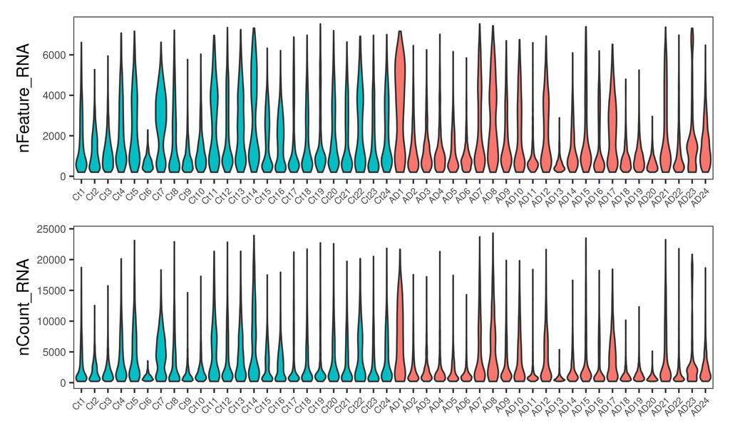

```r
meta1 = SeuratObject@meta.data
write.table(meta1, file=paste0(outdir, 'meta.seurat.raw.tsv'), quote = FALSE, sep = '\t', row.names = FALSE)
meta1 = meta1[rev(order(meta1$Diagnosis)), ]
meta1$sid = unsplit(lapply(split(meta1, meta1$Diagnosis), function(x) paste0(c(AD = 'AD', Control = 'Ct')[x$Diagnosis[1]], as.integer(factor(x$projid, level = unique(x$projid))))), meta1$Diagnosis)
meta1$sid = factor(meta1$sid, levels = unique(meta1$sid))
theme_bw2 = function() theme_bw() + theme(panel.grid = element_blank())
p1 = ggplot(meta1, aes(x = sid, y = nFeature_RNA, fill = Diagnosis)) + geom_violin(width = 0.8, scale = 'width') + theme_bw2() + theme(legend.position = 'none', axis.text.x = element_text(angle = 45, size = 6, hjust = 1), axis.text.y = element_text(size = 7)) + xlab(NULL)
p2 = ggplot(meta1, aes(x = sid, y = nCount_RNA, fill = Diagnosis)) + geom_violin(width = 0.8, scale = 'width') + theme_bw2() + theme(legend.position = 'none', axis.text.x = element_text(angle = 45, size = 6, hjust = 1), axis.text.y = element_text(size = 7)) + xlab(NULL)
print(p1 / p2)
```

We can also use FeatureScatter to visualize feature-feature relationships per donor.

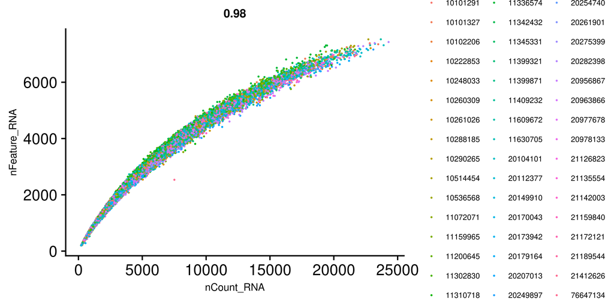

```r
SeuratObject@meta.data$projid = factor(SeuratObject@meta.data$projid)
p3 = FeatureScatter(SeuratObject, feature1 = "nCount_RNA", feature2 = "nFeature_RNA", pt.size=0.1, group.by='projid') + theme(title=element_text(size=8), legend.text=element_text(size=6), legend.title=element_text(size=7))
print(p3)
```

Perform some simple quality control (QC) by first filtering out cells that have unique gene counts over 6,000 or less than 200. The filter on percent.mt has no actual effect here and is just used for illustration purpose.

```r
SeuratObject
```

```
## An object of class Seurat
## 17775 features across 70634 samples within 1 assay
## Active assay: RNA (17775 features)
```

```r
SeuratObject = subset(SeuratObject, subset = nFeature_RNA > 200 & nFeature_RNA < 6000 & percent.mt < 5)
SeuratObject
```

```
## An object of class Seurat
## 17775 features across 69787 samples within 1 assay
## Active assay: RNA (17775 features)
```

After QC, normalize the count data using Seurat’s SCTransform function. This may take a while to finish.

```r
SeuratObject = SCTransform(SeuratObject, verbose = TRUE)
```

Extract gene-level statistics and make plots such as the detection rate.

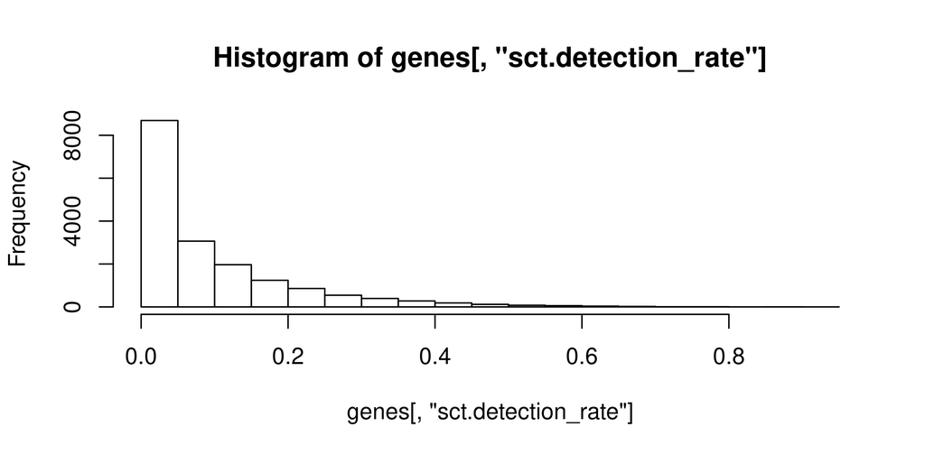

```r
genes = SeuratObject@assays$RNA@meta.features[rownames(SeuratObject), ]
genes = data.frame(genes, SeuratObject@assays[['SCT']]@meta.features, row.names = rownames(genes), stringsAsFactors = FALSE)
hist(genes[, 'sct.detection_rate'])
```

Perform dimensionality reduction by PCA.

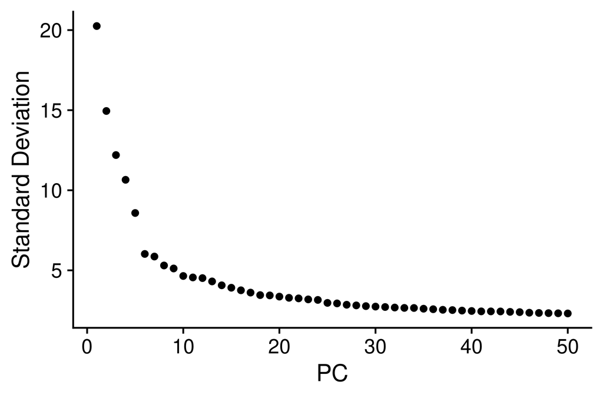

```r
SeuratObject = RunPCA(SeuratObject, verbose = FALSE)
#Plot PCA elbow
ElbowPlot(SeuratObject, ndims = 50)
```

After inspecting the elbow plot, we choose principal components 1:30 for UMAP/tSEN visualization and clustering.

```r
SeuratObject = RunUMAP(SeuratObject, dims = 1:30, verbose = FALSE)
SeuratObject = RunTSNE(SeuratObject, dims = 1:30, verbose = FALSE)
SeuratObject = FindNeighbors(SeuratObject, verbose = FALSE)
SeuratObject = FindClusters(SeuratObject, resolution = 0.8, verbose = FALSE)
```

Plot UMAP.

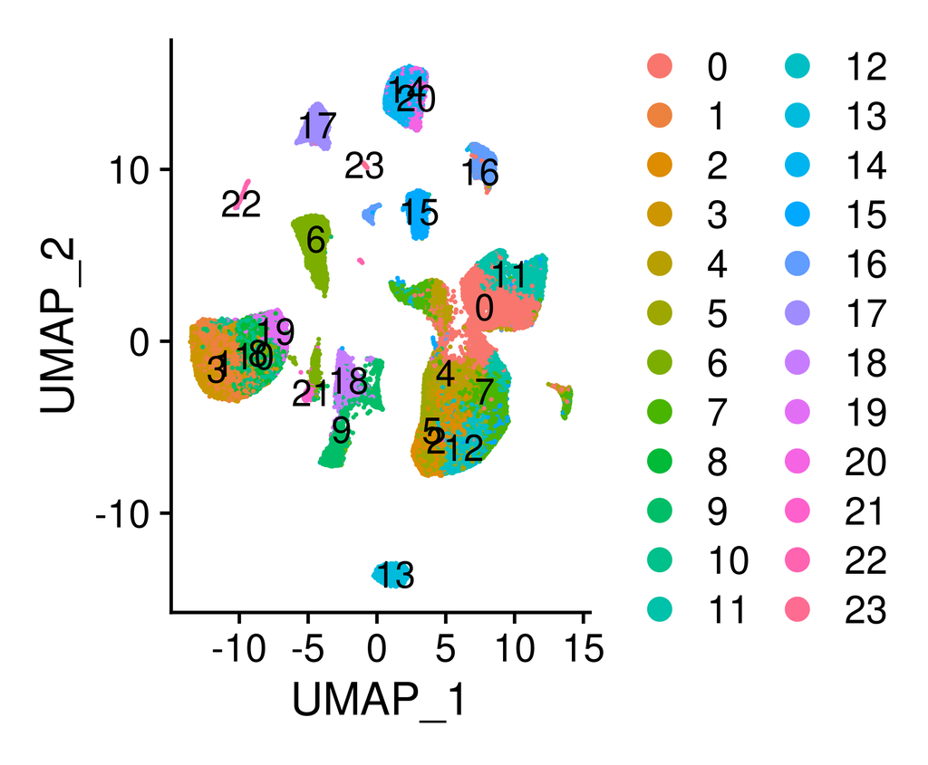

```r
p1 <- DimPlot(SeuratObject, reduction = "umap", label = TRUE)
print(p1)
```

Save the SeuratObject into a file.

```r
saveRDS(SeuratObject, file = paste0(outdir, 'SeuratObject.RDS'))
```

A precomputed version of the SeuratObject file is available at https://www.synapse.org/#!Synapse:syn26477245